# Nested vs Decoupled: model adjustment

# Nested vs Decoupled scales

We will build two objects, `nest.ls` and `dec.ls`, retaining *nested* and *decoupled* multiscale rasters, respectively.

```r
#if installing is needed:
#devtools::install_github("wilsonfrantine/landscapeDecoupler")
library(landscapeDecoupler)
library(raster)
```

## Importing landscape data

We’ll first define some objects that will be needed to extract landscape information from our raster file.

### Buffers

In this example with euglossini dataset, we’ll explore buffers (`b`) from 500 m to 3000 m with a regular interval (but it doesn’t have to be) of 500 m; so: 500 m, 1000 m, 1500 m, 2000 m, 2500 m and 3000 m.

```r
b <- c(500,1000,1500, 2000, 2500, 3000)
```

### Raster

Then we will bring in a raster (`r`) with the whole landscape we will explore in this example

```r
r <- raster(system.file("extdata/raster.grd", package = "landscapeDecoupler"))
```

Now we can read some sampling sites from a shape file.  
*IMPORTANT:* It is required you provied a field in shape files called “id” which will be used as unique identifier.

### Sampling Points

```r
p <- read_points(system.file("extdata/pnts.shp", package = "landscapeDecoupler"), type="shp")
```

> *Note:* `r` and `p` are both native object in `landscapeDecoupler`, so *you can access* this same data by *typing* `r` or `p` in your console or code.

To check if everything loads properly, we can look at the plot.

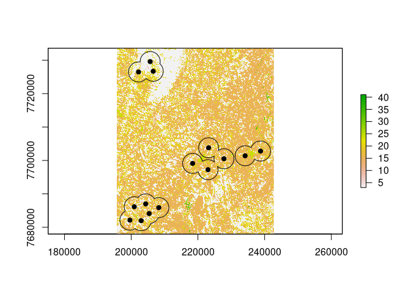

```r
plot(r)
points(p, pch=19)
plot(buffer(p, b[length(b)]), add=T)
```

## Creating multiscale objects

### Nested landscape

```r
nest.ls <- nestedscales(r, p , b)
```

Plotting scales for the first site:

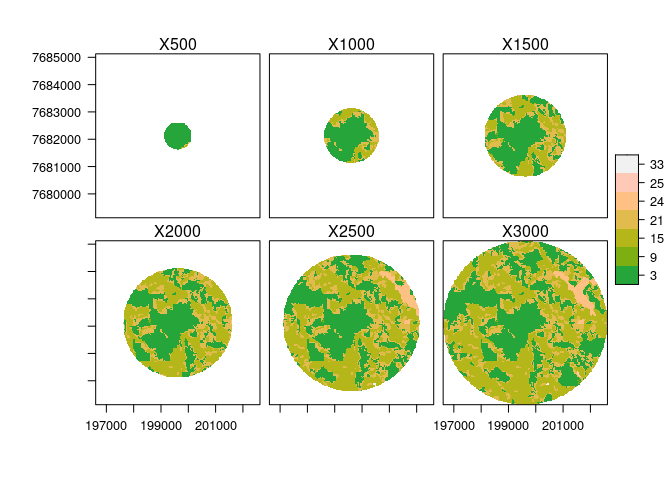

```r
multiplot(nest.ls$p01, pallete = "viridis")
```

### Decoupled landscape

```r
dec.ls <- decouple(r, p, b)
```

plotting

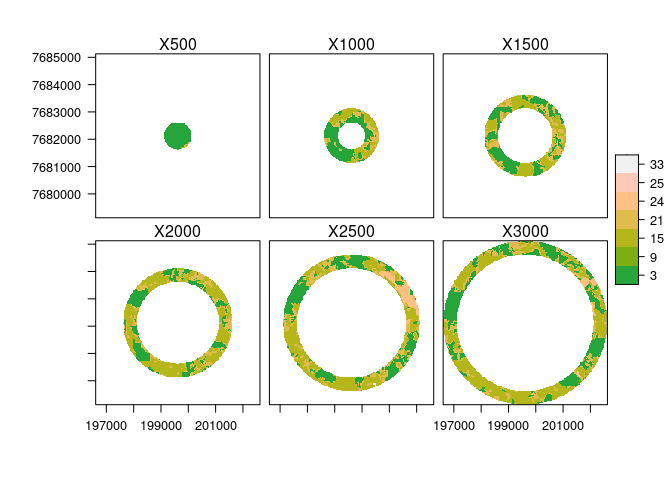

```r
multiplot(dec.ls$p01, pallete ="viridis")
```

## Calculating metrics

In `landscapeDecouple` it is quite simple to retrive metrics from multiscale objects taking advantage of the package `landscapemetrics` (hereafter `lsm`). We can use the function `calc_lsm` to apply any metric implemented in `lsm`:

### Nested

For the nested landscape approache

```r
nest.lsm <- calc_lsm(nest.ls, metric=c("shdi", "pland"))
tail(nest.lsm)
```

```
## # A tibble: 6 × 7
##   site  layer level     class id    metric   value
##   <fct> <fct> <fct>     <fct> <fct> <fct>    <dbl>
## 1 p15   X3000 class     15    <NA>  pland  59.9
## 2 p15   X3000 class     21    <NA>  pland  17.9
## 3 p15   X3000 class     24    <NA>  pland   4.49
## 4 p15   X3000 class     25    <NA>  pland   0.160
## 5 p15   X3000 class     29    <NA>  pland   0.0710
## 6 p15   X3000 landscape <NA>  <NA>  shdi    1.08
```

### Decoupled

For the decoupled approach

```r
dec.lsm <- calc_lsm(dec.ls, metric=c("shdi", "pland"))
tail(dec.lsm)
```

```
## # A tibble: 6 × 7
##   site  layer level     class id    metric   value
##   <fct> <fct> <fct>     <fct> <fct> <fct>    <dbl>
## 1 p15   X3000 class     4     <NA>  pland   0.0484
## 2 p15   X3000 class     15    <NA>  pland  55.7
## 3 p15   X3000 class     21    <NA>  pland  15.5
## 4 p15   X3000 class     24    <NA>  pland   8.94
## 5 p15   X3000 class     29    <NA>  pland   0.0967
## 6 p15   X3000 landscape <NA>  <NA>  shdi    1.16
```

## Comparing metrics behavior

First, let’s take a look at how the landscape metrics behave in both multiscale strategies.  
In order to do so, we will first combine both data frames (`bind_rows()`) to make it easier to plot.

```r
library("dplyr")
# Herein I'm using the pipe ( %>% ) operator by importing dplyr library.
# If you don't know it, take a look at Rstudio and tydiverse documentation.
# The pipe make the code easier for humans to read it.
# you can look at the actions from left to right taking what is happening
# at left and aplying the function at the right of the pipe operator.
combined.lsm <- nest.lsm %>% mutate(., strategy="nested") %>%
  bind_rows(., mutate(dec.lsm, strategy="decoupled")) %>%
  mutate(.,
          site     = as.factor(site),
          layer    = as.factor(layer),
          level    = as.factor(level),
          class    = as.factor(class),
          metric   = as.factor(metric),
          strategy = factor(strategy, levels = c("nested", "decoupled") )
         )
combined.lsm %>% head()
```

```
## # A tibble: 6 × 8
##   site  layer level     class id    metric  value strategy
##   <fct> <fct> <fct>     <fct> <fct> <fct>   <dbl> <fct>
## 1 p01   X500  class     3     <NA>  pland  96.6   nested
## 2 p01   X500  class     15    <NA>  pland   1.60  nested
## 3 p01   X500  class     21    <NA>  pland   1.81  nested
## 4 p01   X500  landscape <NA>  <NA>  shdi    0.172 nested
## 5 p01   X1000 class     3     <NA>  pland  62.6   nested
## 6 p01   X1000 class     15    <NA>  pland  21.9   nested
```

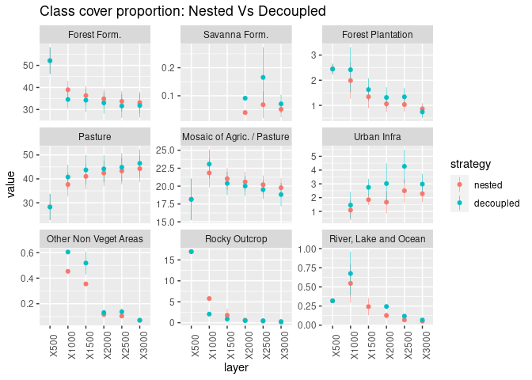

```r
library(ggplot2)

# To rename the subplots with classes names instead of its values
class.codes <- system.file("extdata/colors.txt", package = "landscapeDecoupler") %>%
 read.table( header = T, sep = "\t") %>%
  filter(value %in% levels(combined.lsm$class)) %>%
  pull(name, value)

#Plotting...
ggplot(
    data    = combined.lsm %>%
               filter(metric=="pland") %>%
               group_by(strategy),
    mapping = aes(x=layer, y=value, color=strategy, fill=strategy)
  )+
  stat_summary(fun.data = "mean_se", size=0.2)+
  labs(title="Class cover proportion: Nested Vs Decoupled")+
  facet_wrap(facets = "class", scales = "free_y",
             labeller = as_labeller(class.codes))+
  theme(
    axis.text.x = element_text(angle=90)
  )+
  scale_fill_manual( values = rep(rgb(1,1,1,0), 2) )
```

> This picture shows the cumulative percentage of the landscape class cover throughout the scales. Notice that they all sum to 100% in each scale, so 50 means 50%, 0.6 is equal to 0.6% and so on…

It is interesting to notice that the decouple strategy is more sensitive to metrics variance between scales. The nested strategy, on the other hand, is always smoother. Since the “nested approach” accumulates the presence of the class in the previous scales, it will be null or suffer with subtle changes quite rarely. Whether this property shall be faced as advantage or disadvantage depends on the purpose and nature of the final analysis.

*What about heterogeneity?*

We can also look at a more complex metrics. Heterogeneity in this scope means how “complex” a landscape might be. In this very example we took the landscape Shannon index as a proxy of heterogeneity since it considers both presence and proportion of the classes in the landscape.

We can plot it pretty much like in the previous plot but filtering the `combined.ls` by `metric=="shdi"` .

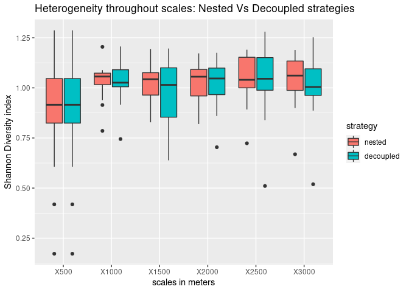

```r
ggplot(
    data    = combined.lsm %>%
               filter(metric=="shdi") %>%
               group_by(layer, strategy),
    mapping = aes(x=layer, y=value, fill=strategy))+
  geom_boxplot()+
  labs(x="scales in meters", y="Shannon Diversity index", title="Heterogeneity throughout scales: Nested Vs Decoupled strategies")
```

As we can see, heterogeneity does not have a clear pathway across the landscapes in any strategy. That somehow derivates from the multifactorial nature of the metric, which depends on both number and “quantity” of landscape components (classes).

Nonetheless the decoupled strategy seems to bring more variation for this metric as well. It is expected since nested scales will share components and its variances as it progressively goes throughout the different scale sizes.

## Multiscale responses

Up to here, we’ve observed that the different strategies resulted in different measurements for the landscape components. However, is it enough to bring different patterns when analyzing the relationship between metrics and biological variables?

Measuring the relationship between landscape components and biological variables across scales is quite useful to understanding ecological process. The `multifit` approach is quite straightforward on that and `landscapeDecoupler` has it natively implemented. We can make it very quickly with the following pipeline:

### Importing biological data

The `landscapeDecouple` has a native object with an example data called `euglossini`. Users can take a look at it just typing *“euglossini”* in the console:

```r
euglossini
```

```
##    site  LS Richness Abundance ComSppAb IntSppAb RareSppAb
## 1   p01 L01        8       223      209       14         0
## 2   p02 L02        9       144      137        6         1
## 3   p03 L03        8       126      117        8         1
## 4   p04 L04        6        77       75        1         1
## 5   p05 L05        9        96       83       11         2
## 6   p06 L06        5       113      100       13         0
## 7   p07 L07        4        11       11        0         0
## 8   p08 L08        5         7        3        4         0
## 9   p09 L09        5        11        9        2         0
## 10  p10 L10        7       107       98        8         1
## 11  p11 L11        8        52       45        5         2
## 12  p12 L12        6        95       85       10         0
## 13  p13 L13        5       110      103        7         0
## 14  p14 L14        6       391      386        3         2
## 15  p15 L15        6       327      322        4         1
```

This dataset comprehends some community data of “orchid bees” (Apidae: Euglossini; details in Carneiro et al. 2021 ). It has five biological variables (columns 3 to 7) and 15 sampling sites (rows). In this example we’ll look at the first two variables ( *“Richness”* and *“Abundance”* ).

> *IMPORTANT*: the *first column* (*site*) is required for any data you will analyze and *must have* the *same values* as the *“id”* sampling sites in the *shape file* you used to extract landscape scales. Otherwise, several parts of the code will fail.

### Multifiting

The very first step is to get things together for our model. Therefore, we must merge the metrics we just extracted (in `nest.lsm` and `dec.lsm` ) with our biodata, `euglossini`.

The `multifit` function expect a very specific structure in a data frame with sampling sites as rows and “biodata+scales” as columns.

The `lsm_calc()` output as we saw in `nest.lsm` and `dec.lsm` are both long format data. You can also use your own pipeline to get it ready for the `multifit` function, but we have a very straightforward function for that.

The `lsm2multifit` function can convert and connect tables with metrics and biodata just as expected by `multifit`. You just need to set the dataframe with metrics (`lsm`) and biological response table (`biodata`). You must also set the level of the metrics and which metrics you want to extract. The `id.col` specify the name of the column that matches the sampling sites in both lsm and biodata tables. It is the “site” by the default.

To the code:

```r
## Nested
# Merging biodata and heterogeneity
nest.mfit.shdi <- lsm2multifit(lsm = nest.lsm,biodata =euglossini,
                               level= "landscape", metrics="shdi",
                               id.col = "site")

# Same for forest cover
nest.mfit.fcov <- lsm2multifit(lsm = nest.lsm,biodata =euglossini,
                               level= "class", class=3, metrics="pland",
                               id.col = "site")

## Decoupled
# Merging biodata and heterogeneity
dec.mfit.shdi <- lsm2multifit(lsm = dec.lsm, biodata=euglossini,
                              level= "landscape", metrics="shdi",
                              id.col = "site")
# Same for forest cover
dec.mfit.fcov <- lsm2multifit(lsm = dec.lsm, biodata=euglossini,
                              level= "class", class=3, metrics="pland",
                              id.col = "site")

head(dec.mfit.fcov)
```

```
##   site  LS Richness Abundance ComSppAb IntSppAb RareSppAb metrics     X500
## 1  p01 L01        8       223      209       14         0   pland 96.58849
## 2  p02 L02        9       144      137        6         1   pland 39.44266
## 3  p03 L03        8       126      117        8         1   pland 87.06257
## 4  p04 L04        6        77       75        1         1   pland 40.74468
## 5  p05 L05        9        96       83       11         2   pland 48.93162
## 6  p06 L06        5       113      100       13         0   pland 13.00640
##      X1000    X1500    X2000    X2500    X3000
## 1 51.31392 39.29256 27.35720 31.67592 34.14917
## 2 36.19654 37.63326 26.68185 31.41535 29.90618
## 3 45.39310 39.43064 39.97866 31.19830 32.16817
## 4 25.80875 32.73810 40.78084 28.13827 29.20388
## 5 28.18697 40.96719 34.81436 24.65980 26.28472
## 6 13.56534 16.07409 26.60076 18.00331 21.54755
```

We have now four objects storing tables for the Shannon index (“shdi”) and proportion of each class in the landscape (“pland”). Each strategy, decoupled and nested, has its own copy of these metrics.

#### Running multifit

To run multifit now is quite easy. You just have to follow the same as usual. Take a look at the code below:

```r
predictors <- c("X500", "X1000","X1500","X2000","X2500","X3000")
#As an alternative you can grab the "predictos" names with this:
#get.scales.names(nest.mfit.shdi)
multifit( mod = "lm", multief = predictors, data = nest.mfit.shdi,
          formula = Richness ~ multief, xlab = "scales", criterion = "R2")
```

[output not shown]

Quite simple, isn’t?

#### Comparing approaches

We have done quite a few things since we started. So, lets remind why we got here.

Our main purpose was to compare two different multiscale strategies ( *decoupled* and *nested* ) looking at the scale of effect. We retrieved two different metrics from landscape using these different approaches. So now we can apply the multifit and compare the R2 and see if they tell us different stories about the data.

##### Richness Vs Heterogeneity

**Nested: Richness Vs Heterogeneity**

```r
predictors <- get.scales.names(nest.mfit.shdi)
multi.nest.het.rich <- multifit( mod = "lm", multief = predictors,
                                 data = nest.mfit.shdi,
                                 formula = Richness ~ multief,
                                 xlab = "scales", criterion = "R2")
```

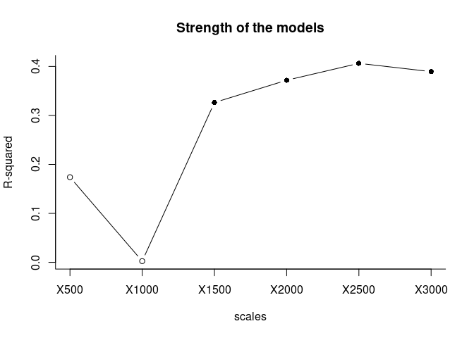

**Decoupled: Richness Vs Heterogeneity**

```r
multi.dec.het.rich <- multifit( mod = "lm", multief = predictors,
                                data = dec.mfit.shdi,
                                formula = Richness ~ multief,
                                xlab = "scales", criterion = "R2")
```

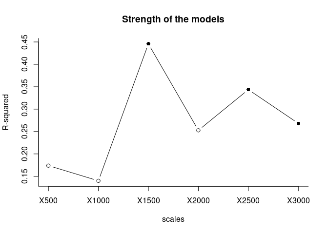

As we can see, we may have different interpretations about the scale of effect depending on which approach we take. In a *nested* approach landscape components will accumulate as we go through the scales (inner to out). Hence, the scale of effect will also accumulate the effect of the previous, as we can see at the first plot. The cumulated effect is then identified at the buffer with 2500 meters.

On the other hand, when we look at the *decoupled* approach, we can see the specific response in each actual scale. In such an approach, landscape components do not accumulate as the buffers size “increase”, so the metrics, and therefore the relationship between biological response and landscape metrics are relative only to that slice of land. We can see that the metric from the buffer with 1500 meters has a stronger relationship with biological responses than its neighbor scales.

We will not go any further into the discussions about what should means a scale of effect or whether coupled or decoupled approach would better represent any concept of it, but it is interesting to notice how can we lose information overlooking one of these two approaches.

Let’s see what happens for a different landscape atribute variable, the forest coverage…

##### Richness Vs Forest Coverage

**Nested approach:**

```r
predictors <- get.scales.names(nest.mfit.shdi)
multi.nest.fcov.rich <- multifit( mod = "lm", multief = predictors,
                                 data = nest.mfit.fcov,
                                 formula = Richness ~ multief,
                                 xlab = "scales", criterion = "R2")
```

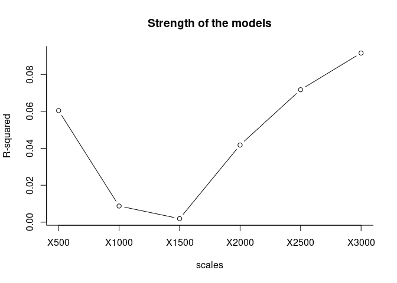

**Decoupled approach:**

```r
get.scales.names(nest.mfit.shdi)
```

```
## [1] "X500"  "X1000" "X1500" "X2000" "X2500" "X3000"
```

```r
multi.dec.fcov.rich <- multifit( mod = "lm", multief = predictors,
                                data = dec.mfit.fcov,
                                formula = Richness ~ multief,
                                xlab = "scales", criterion = "R2")
```

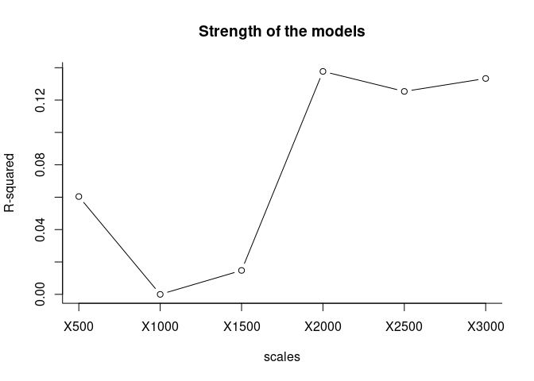

As we can see Richness and Forest Cover do not seem to have a very strong relationship since R2 is quite close to 0 in both approaches. Nonethelless, the **decoupled** approach seems to be a bit more sensitive, as we can see by the higher R2 levels and the subtle change in R2 variation through scale against the smooth one in the **nested** approach.

Moreover, while X2000 and X2500 seem to be less important in the nested strategy, the decoupled strategy display a more prominent e equal response for the larger scales. That is because the very nature of the **nested** strategy, wherein the residual effect of the previous smaller scale noises the effect next one. As we can see, in this case the heterogeneity has no relationship with abundance in the smaller scales, but this change in the larger ones. Since nested approach acumulate the landscape components from the smaller ones this lack of relationship is also inherited from the larger scales. This effect is always expected regardless of the strength or direction of the relationship.

#### Abundance VS Heterogeneity

We can now take a closer look at a different biological variable, the abundance. Since we have the dataset for the two metrics (shdi and pland / fcov) with all biological variables, we only need to change the formula in the function.

**Nested: Abundance VS Heterogeneity**

```r
predictors <- get.scales.names(nest.mfit.shdi)
multi.nest.het.abund <- multifit( mod = "lm", multief = predictors,
                                 data = nest.mfit.shdi,
                                 formula = Abundance ~ multief,
                                 xlab = "scales", criterion = "R2")
```

```
## The model including the effect 'X3000' was the best model according to the specified criterion (R2, which.max)
```

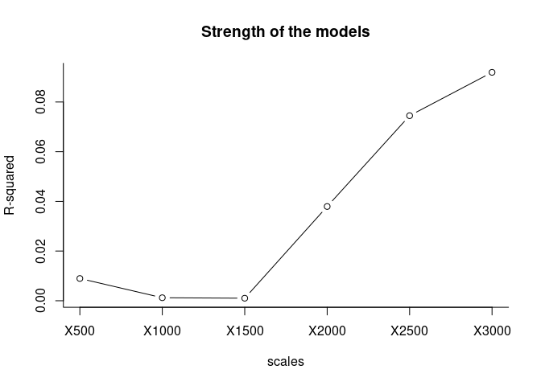

**Decoupled: Abundance VS Heterogeneity**

```r
multi.dec.het.abund <- multifit( mod = "lm", multief = predictors,
                                data = dec.mfit.shdi,
                                formula = Abundance ~ multief,
                                xlab = "scales", criterion = "R2")
```

```
## The model including the effect 'X3000' was the best model according to the specified criterion (R2, which.max)
```

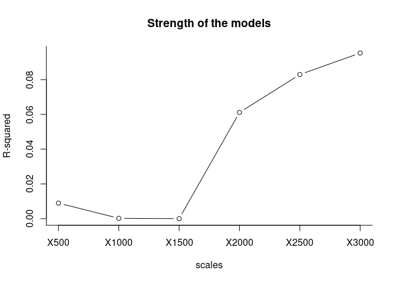

In this comparison we don’t see much since heterogeneity usually explain less than 10% of euglossini abundance in this dataset. We must bear in mind that we tested no requirements of linear models, and all comparisons are just illustrative. We are not looking at the best models, only the trend between two strategies over the same dataset.

Nonetheless, we can see the same noisy effect as we described for Richness VS Forest Cover above.

#### Abundance Vs Forest Cover

Let’s see if the same happens for Abundance VS Forest Cover:

**Nested: Abundance VS Forest Cover**

```r
predictors <- get.scales.names(dec.mfit.fcov)
multi.nest.fcov.abund <- multifit( mod = "lm", multief = predictors,
                                 data = nest.mfit.fcov,
                                 formula = Abundance ~ multief,
                                 xlab = "scales", criterion = "R2")
```

```
## The model including the effect 'X2000' was the best model according to the specified criterion (R2, which.max)
```

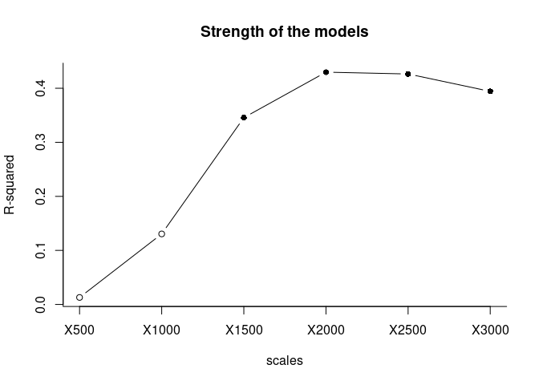

**Decoupled: Abundance VS Forest Cover**

```r
multi.dec.fcov.abund <- multifit( mod = "lm", multief = predictors,
                                data = dec.mfit.fcov,
                                formula = Abundance ~ multief,
                                xlab = "scales", criterion = "R2")
```

```
## The model including the effect 'X2000' was the best model according to the specified criterion (R2, which.max)
```

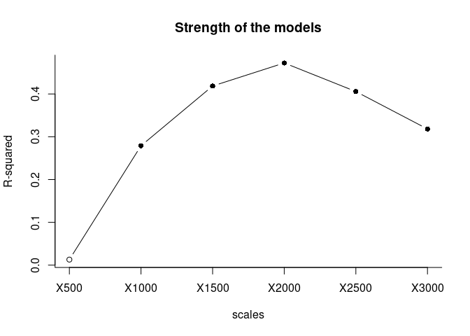

Now we have something more interesting. Here we can see that both approaches identified the same scale of effect through the landscape analyzed. Nonetheless, we must highlight two important questions. At first, the shape of the R2 curves is quite different. Although both strategies detected X2000 as the peak of the R2 curve, we can clearly detect the decay after X2000 in the *decoupled* while in the *nested* strategy it seems to be more as a plato after X2000. Depending on the ecological question or study purpose, we may lose important information by considering only the *nested* approach.

## Conclusions

As we just saw, it is quite a bit risky to get committed with a single strategy. While the *nested* approach has the advantage to almost never get a zero metrics (if it exists in the analyzed landscape) its nested nature make the responses equally smooth and may end on an overlook of some important features of the data. On the other hand, the *decoupled* strategy is quite sensitive to detect the scale of effect but might be deceivable to look at only this single approach since in nature things work together.

There are no silver bullets, but the **decoupled** approach can give us a level of detail that the **nested** approach usualy overlooks. We must always consider our objectives and questions and decide which one might be better. I encourage you to look at both as always as possible.

I hope you find this helpful.

Cheers.

| Dr. Wilson Frantine-Silva |
| --- |

## References

*Lázaro Carneiro, Milton C. Ribeiro, Willian M. Aguiar, Camila Priante, Wilson Frantine-Silva, Maria C. Gaglianone*  
[Bee responses to landscape composition on coupled and decoupled multiscale approaches](http://doi.org/10.21203/rs.3.rs-750143/v1) - Pre-print.

*Lázaro Carneiro, Willian M. Aguiar, Camila Priante, Milton C. Ribeiro, Wilson Frantine-Silva, Maria C. Gaglianone*  
[The Interplay Between Thematic Resolution, Forest Cover, and Heterogeneity for Explaining Euglossini Bees Community in an Agricultural Landscape](http://dx.doi.org/10.3389/fevo.2021.628319). *Front Eco Evol 2021*